# Coursework Report

*N* removed NAs: 3

*N* removed typo: 1

*N* removed <18: 26

*N* total clean: 120

| Group | *N* | *M*<sub>age</sub> | *M*<sub>rating</sub> |
| --- | --- | --- | --- |
| Control | 56 | 20.73 | 6.90 |
| Experim | 64 | 20.86 | 5.52 |

**Main analysis results**

[interactive chart not shown]

[figure not shown]

[interactive chart not shown]

# Coursework Report

Analysing Data, Spring 2020

# Methods

## Design

The experiment was completed in order to test the replicability of Elliot et al. (2010) in which his study demonstrated the link between the colour red and perceived attraction of a male individual to a female. The study will show a link between the colour red and perceived attraction, showing that the result from Elliot et al. (2010) were replicable.

The study carried out utilises the independent measures experimental design as those participants assigned to the experimental group were shown a monochromatic image of a man on a red background for 5 seconds, and in the control group the same monochromatic image was presented on a white background, as per the original study (Francis, 2013). Thus, the operationalised independent variable being changed is the colour of the background of the image. The participants were asked to rate the man presented in terms of how attractive they perceived them to be on a scale of 1-9 as per the original study, where a rating of 1 suggests no attraction, and a rating of 9 suggests a very high level of attraction. Therefore, the dependent variable that is being measured is the perceived attractiveness of the individual.

The results obtained will show a higher attraction rating value obtained when the picture presented is on a red background, and so shows Elliot et al. (2010) was replicable. In order to ensure the results obtained are significant, meaning that they are not due to chance, a t-test will be completed on the mean values calculated.

# Results

In order to analyse the results obtained, a composite score was calculated, whereby the response ratings for the 3 questions asked were used to calculate a mean value for each participant. Using these values, a mean per condition was calculated and graphed onto a means plot, as shown in Figure 1.

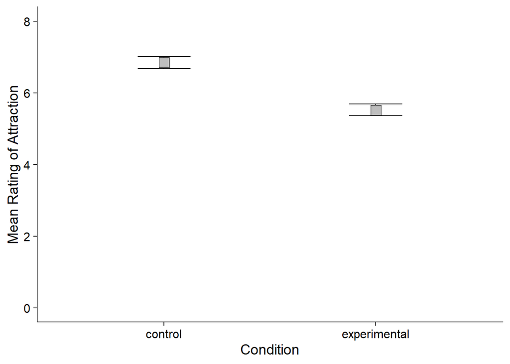

**Figure 1: The Mean Rating of Attraction for Each Condition.**

It was calculated that the mean attractiveness rating for the experimental group was 5.52 out of 9, compared to the mean of the control group, which was 6.91 out of 9. From this trend in data, one can observe that the participants of the control group, where the image was shown on a white background, found the man presented to be more attractive by a rating of 1.39 on average.

```
##
##  Two Sample t-test
##
## data:  opinion_comp by group
## t = 11.099, df = 119, p-value < 0.00000000000000022
## alternative hypothesis: true difference in means is not equal to 0
## 95 percent confidence interval:
##  1.138397 1.632802
## sample estimates:
##      mean in group control mean in group experimental
##                   6.906433                   5.520833
```

**Figure 2: t-test Results.**

# Discussion

The results of this replication show that the participants rated a man as being significantly more attractive when the monochromatic image was presented on a white background when compared to the same image on a red background. This is confounding to what was hypothesised and observed in the original study, however after analysing the data it was determined that the results obtained through this replication were statistically significant, and therefore the hypothesis for this study was successfully tested (Francis, 2013).

The original study completed by Elliot et al. (2010) was critiqued for its small sample size, therefore the generalisability of the results were questionable (Elliot & Maier, 2013). Following this line of critique this current replication that was completed had a considerably larger sample size comparatively, and so consequently the generalisability of results to the population were increased.

When compared to the original study by Elliot et al. (2010) the results found contrasts, as in the original it was found that the red condition resulted in a higher perceived attraction (Francis, 2013). When a replication study was completed by Hesslinger et al. (2015) the results obtained showed no significant difference in the conditions when a differing gender factor was introduced. This result attained was further supported by Peperkoorn et al. (2016) who similarly replicated the study to find there to be no significant difference in conditions, when controlling for other factors including sexuality, age, and relationship. The implication of this is that all results obtained differ substantially, so when one looks at these studies together the effect of the colour red on perceived attraction remains inconclusive.

It would, however, be presumptuous to believe that this current replication study offers the full picture of the effect of colour on attraction as it has a long and complicated biological, social, and cultural history (Little & Hill, 2007). It would be well worth this relationship being studied further due to differing results claiming to be statistically significant, therefore remaining inconclusive. Furthermore, statistically significant research does not imply causation, simply presents a high correlation of two variables (Hutchings, 2004). Future studies into this should ensure to keep a large sample size, as well as controlling for external factors such as gender, sexuality, age, and relationship status (Peperkoorn et al., 2016).

We are still far from understanding and proving the existence of a relationship between the colour red and perceived attraction. It is important to establish this due to various economic, biological, and social reasons, consequently further research should endeavour to address the lacking research surrounding this topic, while considering the factors mentioned previously.

# References

Elliot, A., & Maier, M. (2013). The red-attractiveness effect, applying the Ioannidis and Trikalinos (2007b) test, and the broader scientific context: A reply to Francis (2013). *Journal Of Experimental Psychology: General*, 142(1), 297-300. doi: 10.1037/a0029592.

Elliot, A., Niesta Kayser, D., Greitemeyer, T., Lichtenfeld, S., Gramzow, R., Maier, M., & Liu, H. (2010). Red, rank, and romance in women viewing men. *Journal Of Experimental Psychology: General*, 139(3), 399-417. doi: 10.1037/a0019689.

Francis, G. (2013). Publication bias in “Red, rank, and romance in women viewing men,” by Elliot et al. (2010). *Journal Of Experimental Psychology: General*, 142(1), 292-296. doi: 10.1037/a0027923.

Hesslinger, V., Goldbach, L., & Carbon, C. (2015). Men in red: A reexamination of the red-attractiveness effect. *Psychonomic Bulletin & Review*, 22(4), 1142-1148. doi: 10.3758/s13423-015-0866-8.

Hutchings, J. (2004). Colour in folklore and tradition?The principles. Color Research & Application, 29(1), 57-66. doi: 10.1002/col.10212.

Little, A., & Hill, R. (2007). Attribution to red suggests special role in dominance signalling. *Journal Of Evolutionary Psychology*, 5(1), 161-168. doi: 10.1556/jep.2007.1008.

Peperkoorn, L., Roberts, S., & Pollet, T. (2016). Revisiting the Red Effect on Attractiveness and Sexual Receptivity. *Evolutionary Psychology*, 14(4), 147470491667384. doi: 10.1177/1474704916673841.